# Coursework Report

*N* removed NAs: 2

*N* removed typo: 1

*N* removed <18: 17

*N* total clean: 131

| Group | *N* | *M*<sub>age</sub> | *M*<sub>rating</sub> |
| --- | --- | --- | --- |
| Control | 68 | 20.4 | 5.36 |
| Experim | 63 | 21.1 | 6.25 |

**Main analysis results**

*t*(129) = -6.34, *p* < .001

[interactive chart not shown]

[figure not shown]

[interactive chart not shown]

# Coursework Report

Analysing Data, Spring 2020

# **Methods**

## Participants

Table 1 *Descriptive statistics for age of all participants*

| *M*<sub>age</sub> | *SD*<sub>age</sub> | *Min* | *Max* |
| --- | --- | --- | --- |
| 20.7 | 1.88 | 18 | 26 |

Table 2 *Descriptive statistics for age of participants in each group*

| *Group* | *N* | *M*<sub>age</sub> | *SD*<sub>age</sub> | *Min* | *Max* |
| --- | --- | --- | --- | --- | --- |
| White | 68 | 20.4 | 1.77 | 18 | 25 |
| Red | 63 | 21.1 | 1.94 | 18 | 26 |

## Design

The current study wanted to assess whether colour influenced ratings of attractiveness in a replication of Elliot et al (2010) Red: Colour and Attraction. We employed an independent measures design to do this. There was 1 independent variable: colour. Participants were randomly assigned to either the red (experimental) or white (control) group. In these groups, participants were shown the same picture of a man in a frame which was white or red. In these conditions, participants answered 3 questions regarding their opinions of the man, on a Likert scale of 1 -9 where a high score indicated more positive opinions of attractiveness whereas as low score indicated negative opinions on attractiveness. These scores were averaged to get a composite score to capture how attractive the male was overall, and this was our dependent variable. These scores allowed us to assess our hypothesis that viewing a different colour frame around an image of a moderately attractive male may influence mean ratings of his attractiveness (scale 1-9). Finally, an independent measures *t*-test was used to analyse the results.

# **Results**

We investigated whether participants would give different ratings of attractiveness to the male depending on colour group to see if there was a relationship. Therefore, we conducted an independent-measures *t*-test. This test indicated that the male in red was given higher ratings of attractiveness (*M* = 6.25) than the male in white (*M* = 5.36). This difference in mean attractiveness ratings of red vs white colour groups was significant (*M*<sub>diff</sub> = -0.89, 95% CI [-1.16, -0.61], *t* (129) = -6.34, *p* = <.001). This means that the colour red influences ratings of attractiveness. Table 3 shows the mean ratings of each question by colour group and Table 4 shows the descriptive statistics of attractiveness ratings for each colour condition. Likewise, Figure 1 depicts a histogram showing the breakdown of mean attractiveness ratings for each group. Figure 2 shows a means plot of attractiveness ratings for each condition.

*Table 3* Summary of mean ratings for each question by condition

| Group | Q1 *M* | Q1 *SD* | Q2 *M* | Q2 *SD* | Q3 *M* | Q3 *SD* |
| --- | --- | --- | --- | --- | --- | --- |
| White | 5.49 | 1.45 | 5.18 | 1.23 | 5.43 | 1.44 |
| Red | 6.27 | 1.37 | 6.19 | 1.31 | 6.29 | 1.21 |

*Table 4* Descriptive statistics for attractiveness ratings of each group

| *Group* | *M*<sub>rating</sub> | *SD*<sub>rating</sub> |
| --- | --- | --- |
| White | 5.36 | 0.84 |
| Red | 6.25 | 0.75 |

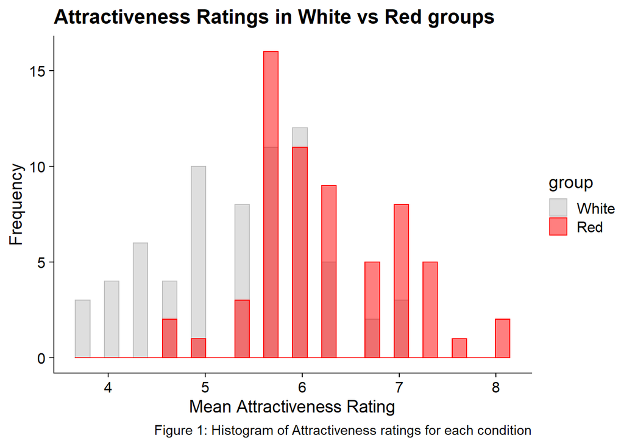

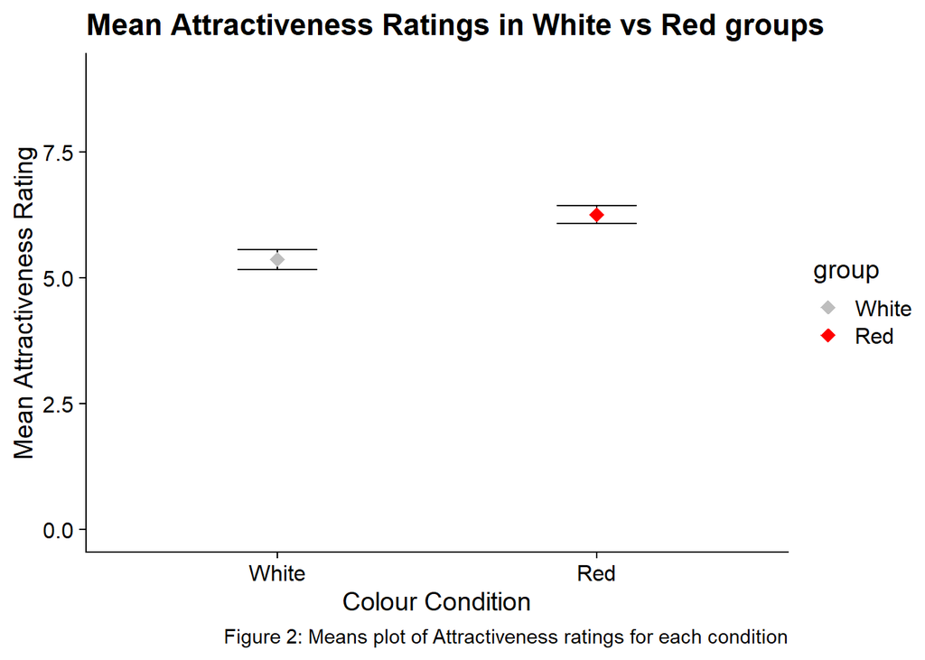

# **Discussion**

With regard to the current research area our pattern of results is quite similar to Elliot et al (2010) who also reordered a significant red effect for women. Both colour condition groups in our experiment scored very similar ratings of attractiveness to those recorded in their research. This result was to be expected as the same procedure was followed. Our research can be used to validate the Elliot et al (2010) research and suggests the red effect is in fact credible. In documenting this link between red and attractiveness we can discredit the notion of female sexuality being a mystery as portrayed in the media. whilst also providing insight for advertisers on what the population find attractive. However, our research is limited as we can only infer how the red effect could be observed in other environments and procedures. For now, our research simply confirms the red effect can be observed using the same procedure as Elliot et al (2010).

Despite our similar results we cannot ignore the conflicting research regarding the red effect. Many researchers fail to reproduce such findings (Peperkoorn, Roberts and Pollet, 2016; Lynn, Giebelhausen, Garcia & Patumanon, 2016). We also cannot be naïve to the acknowledged publication bias seemingly present in the Elliot et al (2010) research in which experiments with null findings are not published. Francis (2013) noted that such experiments may have been run in a way which made rejection of the null hypothesis more likely. Similarly, Klein et al (2019) reported that stronger effect sizes have been found in the original research group (Elliot & Niesta, 2008) than independent researchers. However, our findings that followed the same procedure suggest this is not true.

We also cannot comment on how these findings generalise to dynamic displays for example on the face such as blushing and red lips. However, it has been observed that redness in women’s face is found to be more attractive by men (Re, Whitehead, Xiao & Perrett, 2011). Likewise, redness in women’s facial lips heightened attractiveness of female faces to males (Stephan & McKeegan, 2010). More research would have to be conducted around this area with regard to how women observed this in men, however. Nevertheless, current research indicates similar findings should be found. For instance, it has been observed that female primates are good a decoding blood flow change (Changizi, Zhang & Shimojo, 2006).

Furthermore, our own findings may indicate that this effect could be detected when observing hair colour. However, there is limited research surrounding this area. Nevertheless, existing literature indicates that red heads are rated consistently less attractive than blondes and brunettes (Feiman & Gill, 1978; Gueguen, 2012b; Swami & Barret, 2011). However, research is inadequate on whether this aversion is seen in females with dyed red hair or with women observing men. Our findings and research consistent with our findings do indicate that the red effect is real but because research has found no effect for hair colour it would be interesting to see if findings extend this far.

Perhaps, our research also implies that red could have an effect on how others perceive themselves to be more attractive with regard to the artificial colour (Attrill, Gresty, Hill, & Barton, 2008). This could be interesting to research to see if how people act when wearing red influences attractiveness to give a possible reason as to why the red effect is observed. Likewise, the style the colour is presented in has been found to influence ratings of attractiveness e.g. formal clothes (Hesslinger, Goldbach & Carbon, 2015). However, no red effect was observed in this research. Therefore, our findings may have been different when comparing the man in a red shirt to a man in a white formal shirt and it could be that style of colour has more influence in ratings of attractiveness.

A variable that was left uncontrolled in our research is a women’s period of ovulation. In primates the colour red is an indication of fertility due to a female’s increased oestrogen levels (Pazda, Elliot & Greitemeyer, 2012) suggesting the red effect in men is most prominent when a female is ovulating. But what about women? Regan (1996) indicated that on the 14th day of the menstrual cycle women experienced the greatest sexual desire. This may signpost a confounding variable in our research that was left uncontrolled that could have affected women’s ratings of attractiveness. Similarly, Schwarz and Singer (2013) found that women of a reproductive age in a red condition were rated as more sexually attractive than those who were menopausal. This could specify that this is only an underlying factor influencing how males interpret red.

A limitation of our research is our results may not generalise to real life contexts such as bars/ restaurants as we completed research in a controlled lab setting with participants being shown a picture of the male rather than observing him themselves. Nonetheless, Guegean (2012a) extended lab findings to hitchhikers and found women wearing red were offered more lifts which is indicative of the red effect we observed in a real life setting where participants are not as likely to be consciously aware of this effect occurring. However, further research has not observed said effect in hypothetical real-life contexts such as a restaurant (Lynn et al, 2016). Additional research would be interesting to see if our results extend further to real life contexts. Although it may be difficult it would be beneficial for the research area.

In closing, our research adds to the growing area of literature surrounding the red effect. We show that, contrary to some studies, the effect appears very much tangible. Likewise, red is commonly associated as something males are attracted to in females, yet our findings extend Elliot et al (2010) that the red-sex link is indeed applicable to men. Furthermore, we also show ways in which red can be used by the sexes to influence attractiveness which is significant for future advertising and discrediting negative media representations of women. Nevertheless, our research did not cover all grounds and future research on dynamic displays of red would be interesting. Equally, seeing whether the time in a women’s menstrual cycle influences ratings could be significant to see if there is a biological underpinning of the red-sex link. As discussed, existing findings do conflict therefore to reach a solid conclusion regarding the red-sex link it would require a significant amount of further studies.

# **References**

Attrill, M. J., Gresty, K. A., Hill, R. A., & Barton, R. A. (2008). Red shirt colour is associated with long-term team success in English football. Journal of sports sciences, 26(6), 577-582.

Changizi, M. A., Zhang, Q., & Shimojo, S. (2006). Bare skin, blood and the evolution of primate colour vision. Biology letters, 2(2), 217-221.

Elliot, A. J., & Niesta, D. (2008). Romantic red: Red enhances men’s attraction to women. Journal of personality and social psychology, 95(5), 1150.

Elliot, A. J., Niesta Kayser, D., Greitemeyer, T., Lichtenfeld, S., Gramzow, R. H., Maier, M. A., & Liu, H. (2010). Red, rank, and romance in women viewing men. Journal of Experimental Psychology: General, 139(3), 399.

Feinman, S., & Gill, G. W. (1978). Sex differences in physical attractiveness preferences. The Journal of Social Psychology, 105(1), 43-52.

Francis, G. (2013). Publication bias in “Red, rank, and romance in women viewing men,” by Elliot et al. (2010). Journal of Experimental Psychology: General, 142(1), 292–296. https://doi.org/10.1037/a0027923

Guéguen*, N. (2012a). Color and women hitchhikers’ attractiveness: Gentlemen drivers prefer red. Color Research & Application, 37(1), 76-78.

Guéguen, N. (2012b). Hair color and wages: Waitresses with blond hair have more fun. The Journal of Socio-Economics, 41(4), 370-372.

Hesslinger, V. M., Goldbach, L., & Carbon, C. C. (2015). Men in red: A reexamination of the red-attractiveness effect. Psychonomic bulletin & review, 22(4), 1142-1148.

Klein, R. A., Ratliff, K. A., Vianello, M., Adams, R. B., Jr., Bahník, Š., Bernstein, M. J., … Nosek, B. A. (2019, November 8). Investigating Variation in Replicability: A “Many Labs” Replication Project. Retrieved from osf.io/wx7ck

Lynn, M., Giebelhausen, M., Garcia, S., Li, Y., & Patumanon, I. (2016). Clothing color and tipping: An attempted replication and extension. Journal of Hospitality & Tourism Research, 40(4), 516-524.

Pazda, A. D., Elliot, A. J., & Greitemeyer, T. (2012). Sexy red: Perceived sexual receptivity mediates the red-attraction relation in men viewing woman. Journal of Experimental Social Psychology, 48(3), 787-790.

Peperkoorn, L. S., Roberts, S. C., & Pollet, T. V. (2016). Revisiting the red effect on attractiveness and sexual receptivity: No effect of the color red on human mate preferences. Evolutionary Psychology, 14(4), 1474704916673841.

Re, D. E., Whitehead, R. D., Xiao, D., & Perrett, D. I. (2011). Oxygenated-blood colour change thresholds for perceived facial redness, health, and attractiveness. PloS one, 6(3)

Regan, P. C. (1996). Rhythms of desire: The association between menstrual cycle phases and female sexual desire. Canadian Journal of Human Sexuality, 5(3).

Schwarz, S., & Singer, M. (2013). Romantic red revisited: Red enhances men’s attraction to young, but not menopausal women. Journal of Experimental Social Psychology, 49(1), 161-164.

Stephen, I. D., & McKeegan, A. M. (2010). Lip colour affects perceived sex typicality and

attractiveness of human faces. Perception, 39(8), 1104-1110.

Swami, V., & Barrett, S. (2011). British men’s hair color preferences: An assessment of courtship solicitation and stimulus ratings. Scandinavian Journal of Psychology, 52(6), 595-600.